# MATH-509: Lab 05

**Daniel Carter**

## Getting Started

Follow the instructions below to copy this notebook and to perform some initial setup.

1. Copy this notebook by selecting `File > Save a copy in Drive`.
2. A new window should open for the copied notebook. Move the new notebook to your course folder in Google Drive by selecting `File > Move` and then selecting the desired folder.
3. Update the name of the notebook by removing "Copy of" and replacing "Username" with your actual username.
4. Update the first cell in the notebook by replacing "Student Name" with your actual name.
5. Mount your Google Drive by running the cell below and accepting the prompts you are presented with.

```python
from google.colab import drive
drive.mount('/content/drive')
```

## Import Statements

Run the cell below to import NumPy, SymPy, and the constant `e` from the math package.

```python
import numpy as np
import sympy as sym
from math import e
```

Run the cell below to import the `gradient_optimization()`, `one_var_grad_plot()`, and `two_var_grad_plot()` functions.

```python
%%capture
!git clone https://github.com/drbeane/MATH_509.git
from MATH_509.utils import *
```

# Function for Problems 1 - 3

The next cell creates a Python function and a SymPy expression to represent the function $f(x)$ shown below. It also creates a SymPy variable `x` and a list to contain that variable. Run this cell as-is.

$$\large f(x) = 100 x^4 + 200 x^ 3 - 800 x^2 + 500 x + 1000$$

```python
f = lambda x : 100*x**4 + 200*x**3 - 800*x**2 + 500*x + 1000
x = sym.Symbol('x')
f_sym = f(x)
f_vars = [x]
```

# Problem 1 - Gradient Ascent (1D)

### Instructions

Fill in the blanks below to perform gradient ascent to find a local maximum for the function $f(x)$. Set the parameters of the `gradient_optimization()` function as follows:

- Set the initial value to $x = -2$.
- Find an $\alpha$ value so that the algorithm converges in **fewer than 10 iterations**.
- Leave `max_iter`, `threshold`, and `verbosity` with the values provided.

```
Iteration 001:  params = [0.9000],  f(params) = 1013.4100
Iteration 002:  params = [0.7376],  f(params) = 1043.4153
Iteration 003:  params = [0.5444],  f(params) = 1076.1567
Iteration 004:  params = [0.4157],  f(params) = 1086.9576
Iteration 005:  params = [0.3830],  f(params) = 1087.5369
Iteration 006:  params = [0.3807],  f(params) = 1087.5397
Iteration 007:  params = [0.3806],  f(params) = 1087.5397

Algorithm converged in 7 steps.
Final parameter estimates: [0.3806]
Optimal value: 1087.5397
```

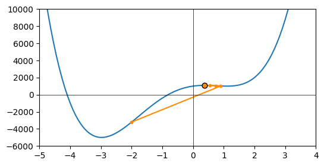

```python
params, param_list = gradient_optimization(
    sym_fn = f_sym,
    vars = f_vars,
    init_vals = [-2],
    alpha = .001,
    mode = 'max',
    max_iter = 100,
    threshold = 0.0001,
    verbosity = 1
)
one_var_grad_plot(f, vars, param_list, xlim=[-5,4], ylim=[-6000, 10000])
```

# Problem 2 - Gradient Descent (1D)

### Instructions

Fill in the blanks below to perform gradient descent to find a local minimum for the function $f(x)$. Set the parameters of the `gradient_optimization()` function as follows:

- Set the initial value to $x = 3$.
- Find an $\alpha$ value so that the algorithm converges to the local minimum that is at approximately $x=1.1$ in **fewer than 50 iterations**.
- Leave `max_iter`, `threshold`, and `verbosity` with the values provided.

Note that there are two local minima for $f(x)$, and in this problem you are asked specifically to find a learning rate that causes the algorithm to converge to the local min near $x=1.1$.

```
Iteration 005:  params = [1.3611],  f(params) = 1046.0143
Iteration 010:  params = [1.2130],  f(params) = 1002.8551
Iteration 015:  params = [1.1556],  f(params) = 996.4460
Iteration 020:  params = [1.1291],  f(params) = 995.0741
Iteration 025:  params = [1.1158],  f(params) = 994.7339
Iteration 030:  params = [1.1090],  f(params) = 994.6435
Iteration 035:  params = [1.1054],  f(params) = 994.6186
Iteration 040:  params = [1.1035],  f(params) = 994.6117
Iteration 045:  params = [1.1025],  f(params) = 994.6097

Algorithm converged in 49 steps.
Final parameter estimates: [1.1021]
Optimal value: 994.6092
```

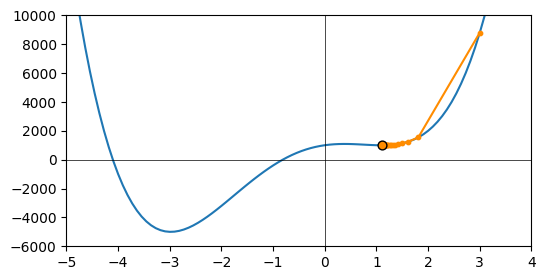

```python
params, param_list = gradient_optimization(
    sym_fn = f_sym,
    vars = f_vars,
    init_vals = [3],
    alpha = .0001,
    mode = 'min',
    max_iter = 100,
    threshold = 0.0001,
    verbosity = 5
)
one_var_grad_plot(f, vars, param_list, xlim=[-5,4], ylim=[-6000, 10000])
```

# Problem 3 - Gradient Descent (1D)

### Instructions

Fill in the blanks below to perform gradient descent to find a local minimum for the function $f(x)$. Set the parameters of the `gradient_optimization()` function as follows:

- Set the initial value to $x = 3$.
- Find an $\alpha$ value so that the algorithm converges to the local minimum that is at approximately $x=-3$ in **fewer than 50 iterations**.
- Leave `max_iter`, `threshold`, and `verbosity` with the values provided.

Note that there are two local minima for $f(x)$, and in this problem you are asked specifically to find a learning rate that causes the algorithm to converge to the local min near $x=-3$.

```
Iteration 005:  params = [-0.8295],  f(params) = -32.0977
Iteration 010:  params = [-2.9623],  f(params) = -4999.8449
Iteration 015:  params = [-2.9821],  f(params) = -5000.8986

Algorithm converged in 16 steps.
Final parameter estimates: [-2.9819]
Optimal value: -5000.8986
```

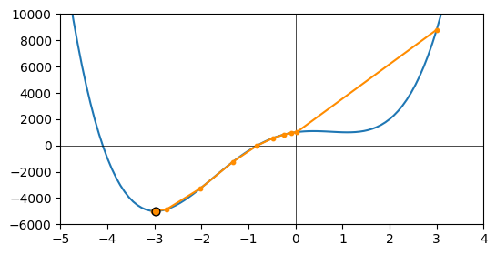

```python
params, param_list = gradient_optimization(
    sym_fn = f_sym,
    vars = f_vars,
    init_vals = [3],
    alpha = .00025,
    mode = 'min',
    max_iter = 100,
    threshold = 0.0001,
    verbosity = 5
)
one_var_grad_plot(f, vars, param_list, xlim=[-5,4], ylim=[-6000, 10000])
```

# Function for Problems 4 - 5

```python
def g(x,y):
    w1 = (x + 2)**2 + 0.25*(y + 1)**2
    w2 = (x + 1)**2 + (y - 3)**2
    w3 = 0.25*(x - 2)**2 + (y - 1)**2
    z = 1000/e**w1 + 700/e**w2 - 2000/e**w3 + 10*(x + y)
    return z

x, y = sym.symbols('x, y')
g_sym = g(x,y) * 2
g_vars = [x, y]
```

# Problem 4 - Gradient Descent (2D)

### Instructions

Fill in the blanks below to perform gradient descent to find a local minimum for the function $g(x,y)$. Set the parameters of the `gradient_optimization()` function as follows:

- Set the initial values to $x = -1$ and $y = -1$.
- Find an $\alpha$ value so that the algorithm converges to the local minimum in **fewer than 50 iterations**.
- Leave `max_iter`, `threshold`, and `verbosity` with the values provided.

```python
params, param_list = gradient_optimization(
    sym_fn = g_sym,
    vars = g_vars,
    init_vals = [-1,-1],
    alpha = .0002,
    mode = 'min',
    max_iter = 100,
    threshold = 0.0001,
    verbosity = 5
)
two_var_grad_plot(g, vars, param_list, xlim=[-5, 5], ylim=[-5, 5])
```

```
Iteration 005:  params = [-0.2139, -0.9588],  f(params) = 33.5109
Iteration 010:  params = [0.0169, -0.8490],  f(params) = -31.6166
Iteration 015:  params = [0.1741, -0.6168],  f(params) = -119.0873
Iteration 020:  params = [0.4556, 0.1299],  f(params) = -1018.2007
Iteration 025:  params = [1.6601, 1.0005],  f(params) = -3832.8764
Iteration 030:  params = [1.9635, 0.9973],  f(params) = -3939.4201
Iteration 035:  params = [1.9879, 0.9975],  f(params) = -3940.1173
Iteration 040:  params = [1.9898, 0.9975],  f(params) = -3940.1216

Algorithm converged in 40 steps.
Final parameter estimates: [1.9898, 0.9975]
Optimal value: -3940.1216
```

# Problem 5 - Gradient Ascent (2D)

### Instructions

Fill in the blanks below to perform gradient ascent to find a local minimum for the function $g(x,y)$. Set the parameters of the `gradient_optimization()` function as follows:

- Set the initial values to $x = -4$ and $y = 2$.
- Find an $\alpha$ value so that the algorithm converges to a local maximum in **fewer than 60 iterations**.
- Leave `max_iter`, `threshold`, and `verbosity` with the values provided.

```python
params, param_list = gradient_optimization(
    sym_fn = g_sym,
    vars = g_vars,
    init_vals = [-4,2],
    alpha = .0005,
    mode = 'max',
    max_iter = 100,
    threshold = 0.0001,
    verbosity = 5
)
two_var_grad_plot(g, vars, param_list, xlim=[-4.5, 4.5], ylim=[-4.5, 4.5])
```

[output not shown]

# Problem 6 - Gradient Descent (4D)

### Background

In this problem, you will be performing gradient descent to find a local minimum of the following function:

$$\large h(w, x, y, z) = w^2 - 7w + x^2 + y^2 + 9y + z^2 - 5z$$

### Instructions

Complete the following steps in the cell below:

1. Define a Python function `h()` to represent the function $h$ from above.
2. Create SymPy symbols `w`, `x`, `y`, and `z`.
3. Use `h()` and the symbols you created to define a SymPy expression to represent $h$.
4. Add the four symbolic variables to a list.
5. Use the `display()` function to display the SymPy expression you created for $h$.

```python
def h(w,x,y,z):
  h = w**2 - 7*w + x**2 + y**2 + 9*y + z**2 - 5*z
  return h
w,x,y,z = sym.symbols('w,x,y,z')
h_sym = h(w,x,y,z)
h_vars = [w,x,y,z]
display(h_sym)
```

**Additional Instructions**

Use the cell below to perform gradient descent to find a local minimum for the function $h(w, z, y, z)$. Set the parameters of the `gradient_optimization()` function as follows:

- Set the initial values to $w=0$, $x=0$, $y=0$, and $z=0$.
- Find an $\alpha$ value so that the algorithm converges to a local minimum in **fewer than 50 iterations**.
- Leave `max_iter`, `threshold`, and `verbosity` with the values provided.

Note: This function has only one local minimum, and the value of the function at that local minimum is approximately -39.

```python
params, param_list = gradient_optimization(
    sym_fn = h_sym,
    vars = h_vars,
    init_vals = [0,0,0,0],
    alpha = .06,
    mode = 'min',
    max_iter = 100,
    threshold = 0.0001,
    verbosity = 5
)
```

[output not shown]

# Data for Problems 7 and 8

In Problems 7 and 8, you will used gradient descent to train a linear regression model with three features on a small training set. The features for the model are denoted by $x^{(1)}$, $x^{(2)}$, and $x^{(3)}$. The model will have the following form:

$$\large \hat y = \beta_0 + \beta_1 x^{(1)} + \beta_2 x^{(2)} + \beta_3 x^{(3)} $$

The cell below provides the training features in an array named `X` and the training target values in an array named `y`. Run this cell as is.

```python
X = [[4.2, 28.4, 8.0],
     [7.2, 33.7, 9.7],
     [0.0, 24.1, 3.1],
     [3.0, 37.6, 6.9],
     [1.5, 20.5, 8.8],
     [0.9, 33.4, 8.9],
     [1.9, 28.3, 0.9],
     [3.5, 31.2, 0.4],
     [4.0, 22.8, 1.7],
     [5.4, 24.0, 8.8]]

y = np.array([12.8, 14.87, 9.62, 16.31, 8.84, 15.52, 11.75, 12.51, 10.37, 11.15])
```

# Problem 7 - Sum of Squared Errors

### Instructions

Complete the following steps in the cell below:

1. Define SymPy symbols `b0`, `b1`, `b2`, and `b3` to represent the model parameters $\beta_0$, $\beta_1$, $\beta_2$, and $\beta_3$.
2. Create a list containing the symbols `b1`, `b2`, and `b3`. (Note that this excludes `b0`. This list will be used in the next step.)
3. Generate predictions for the training set. The easiest way to do this would be to use matrix multiplication to multiply the feature array and the list from step 2 above, and then add in the intercept term `b0`.
4. Print the shape of the prediction array and then print the prediction array itself.

If the steps above are performed correctly, then the prediction array will be a 1-dimensional array with 10 entries. The entries will be symbolic expressions written in terms of the model parameters.

```python
b0,b1,b2,b3 = sym.symbols('b0,b1,b2,b3')
b_list = [b1,b2,b3]
pred = np.matmul(X, b_list) + b0
pred.shape
```

**Additional Instructions**

Complete the following steps in the cell below:

1. Calculate a 1-dimensional array to store the errors for each of the 10 predictions.
2. Use the errors to calculate the sum of squared errors for the model as calculated on the training set.
3. Simplify the sum of squared errors expression. If the expression is named `sse`, then you can perform the simplification using the following line of code: `sse = sym.simplify(sse)`
4. Use the `display()` function to display the simplified expression for the sum of squared errors.

Note that the expression for sum of squared errors is written in terms of the model parameters.

```python
errors = y - pred
sse = np.sum(errors**2)
sse = sym.simplify(sse)
display(sse)
```

**Additional Instructions**

Before finding the optimal parameters, we will score a single model by calculating its sum of squared errors. The model we will score is shown below. Use the `subs()` function to plug the appropriate parameter values into your expression for sum of squared errors and print the result.

```python
initial_score = sse.subs({b0:2,b1:.2,b2:.2,b3:.4})
print(initial_score)
```

# Problem 8 - Finding Optimal Parameters

### Instructions

Use the cell below to perform gradient descent to find a local minimum for the sum of squared errors expression found in Problem 7. Set the parameters of the `gradient_optimization()` function as follows:

- Set each of the initial parameter values to 0.
- Find an $\alpha$ value so that the algorithm converges to a local minimum in **fewer than 100 iterations**.
- Set `max_iter=200`, `threshold=0.0001`, and `verbosity=5`.

Note: The sum of squared errors has only one local minimum, and the value of the function at that local minimum is slightly larger than 2.

```python
sse_list = [b0]+b_list
params, param_list = gradient_optimization(
    sym_fn = sse,
    vars = sse_list,
    init_vals = [0,0,0,0],
    alpha = .000095,
    mode = 'min',
    max_iter = 200,
    threshold = 0.0001,
    verbosity = 5
)
```

[output not shown]

# Submission Instructions

1. The cell below will generate an HTML render of your notebook within the same Google Drive folder in which you stored this notebook. Adjust the path for your notebook in the cell below as needed.
2. Restart your notebook and run it from start to finish.
3. If the notebook executes without error, download the HTML export of the notebook and then upload it to Canvas. Make sure to carefully review the contents of the HTML export to ensure that everything is displayed correctly.
4. Click on "Share" in the upper-right corner of this notebook. Then select "Anyone with the link" from dropdown. Click "Copy Link" and paste the copied link as a comment in your submission on Canvas.

```python
%%capture
import time
time.sleep(30)
!jupyter nbconvert --to html /content/drive/MyDrive/MATH_509/Lab_05_dcarter8.ipynb
```